# survex: model-agnostic explainability for survival analysis | by Mikołaj Spytek | ResponsibleML | Sep, 2022 | Medium

Published in

ResponsibleML

[Mikołaj Spytek](https://medium.com/@spytekm?source=post_page-----94444e6ce83d--------------------------------)

Sep 19

·

7 min read

·

# survex: model-agnostic explainability for survival analysis

> In this blog, we’d like to cover how model explainability can help make informed choices when working with survival models by showcasing the capabilities of the survex R package.

[figure not shown]

# Survival analysis and explainability

When talking about machine learning, most people have classification and regression tasks in mind, as they are the most popular. However, these tasks are not the only application of ML models. Another popular one, especially in the fields of medicine and insurance, is survival analysis, dealing with predicting the time until a certain event (e.g., patient death, machine breakdown, etc.) occurs.

You can learn about it in [this blog](https://medium.com/responsibleml/responsible-machine-learning-for-survival-analysis-e0a24939d49f), but long story short, survival models (most often) predict a survival function. It tells us what is the probability of an event not happening until a given time *t*. The output can also be a single value (e.g., risk score) but these scores are always some aggregates of the survival function and this naturally leads to a loss of information included in the prediction.

The complexity of the output of survival models means that standard explanation methods cannot be applied directly.

Because of this, we (I and the team:

[Mateusz Krzyziński](https://medium.com/u/5c9b79209723?source=post_page-----94444e6ce83d--------------------------------)

,

[Hubert Baniecki](https://medium.com/u/6028e9b8f883?source=post_page-----94444e6ce83d--------------------------------)

, and

[Przemyslaw Biecek](https://medium.com/u/57dd112ef71e?source=post_page-----94444e6ce83d--------------------------------)

) developed an R package — survex, which provides explanations for survival models. We hope this tool allows for more widespread usage of complex machine learning survival analysis models. Until now, simpler statistical models such as Cox Proportional Hazards were preferred due to their interpretability — vital in areas such as medicine, even though they were frequently outperformed by complex machine learning models.

[figure not shown]

[Cheatsheet highlighting the main functionalities of the survex package](https://github.com/ModelOriented/survex/blob/main/misc/cheatsheet.pdf)

In this blog, I’d like to present the main functionalities of `survex` and explain how to interpret the explanations.

# What influences the overall model predictions?

Knowing which variables are the most important for the model of interest when making predictions is critical. This information can be compared with domain knowledge and used to assess if the predictions are made based on correct variables or if the model is using something unexpected to provide outputs. Explanations of this kind can be calculated via the `model_parts()` function of `survex`.

To measure the global importance of variables, we use [permutational variable importance](https://medium.com/responsibleml/basic-xai-with-dalex-part-2-permutation-based-variable-importance-1516c2924a14). Intuitively, it works as such: we permute one variable (column) of the dataset and make predictions using this permuted input. Then we calculate a performance metric and see how much the performance of the model worsened after the permutation in comparison with the baseline result. We repeat this for all variables in the dataset.

We interpret the result as follows: the higher the decrease in performance of the model after permuting a variable, the more important the variable is for making the prediction — so the variables higher on the plot are the most important ones. Additionally, if we use a time-dependent metric, we can see if some variables are more important at certain times of the study.

Below you can see the permutational variable importance for a Random Survival Forest model.

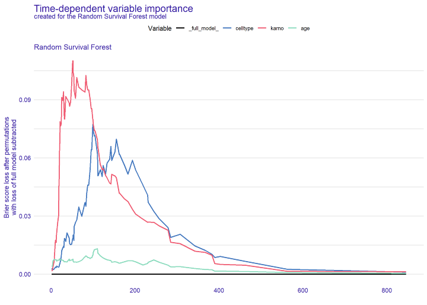

Variable importance for a Random Survival Forest model

We can see that the `karno` variable is the most important until time ~100 and then `celltype` takes the lead.

# How does the prediction change on average?

Another question a user of a survival model might ask is: how do model predictions depend on individual variables? Of course, this is a difficult question to answer because models are complex and variables are often dependent on one another but partial dependence profiles, accessible by the `model_profile()` function in `survex`, present this kind of information.

These profiles are an aggregation of “what-if” explanations across an entire dataset. To calculate them, we change the value of a single variable for each observation, observe how the prediction changes and present the average response to the change on the plot.

Below, the partial dependence profiles are presented for two variables — a categorical one — `celltype` and a continuous one — `karno`.

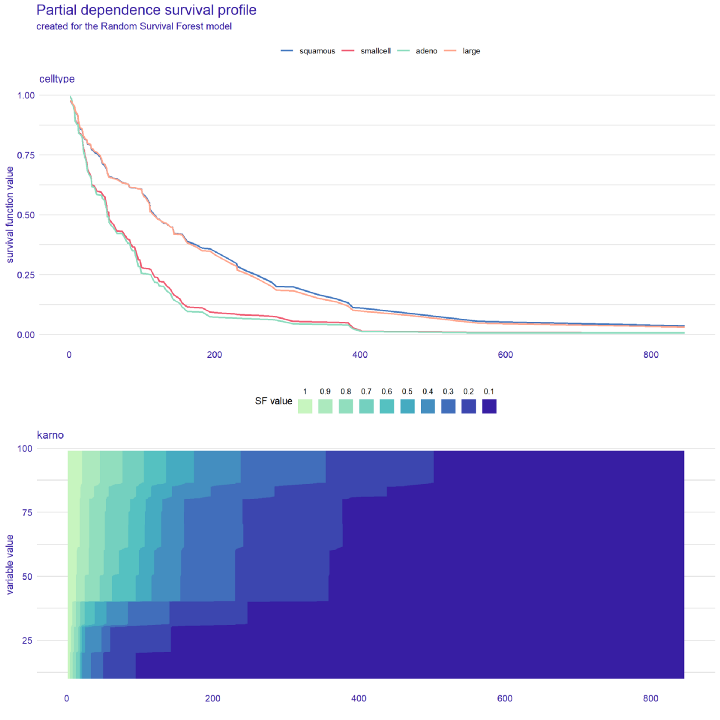

Partial dependence profiles for a Random Survival Forest

We see that celltypes `large` and `squamous` are almost synonymous to the model, as are `adeno` and `smallcell` with the latter ones having much worse survival chances. We also observe that the observations with high values of the continuous `karno` variable are more likely to survive longer.

# What influences the prediction for a selected observation?

The general knowledge of how the model works is very useful but often we want to know what factors contribute to the prediction for a single chosen observation.

This can be done via the [SurvSHAP(t)](https://arxiv.org/abs/2208.11080) and [SurvLIME](https://doi.org/10.1016/j.knosys.2020.106164) methods, accessible by the `predict_parts()` method in `survex`.

Below, both of these explanations for the same observation are presented. They show that for this observation, the survival function is below average, and the main contributions are the `celltype` and `age` variables. SurvSHAP(t) shows the contribution of each variable separately for each timepoint, whereas SurvLIME only describes the overall contribution. For the SurvLIME explanation, the survival function of the surrogate model is also plotted together with the black-box model explanation as this informs us how close the explanation really is to the actual prediction.

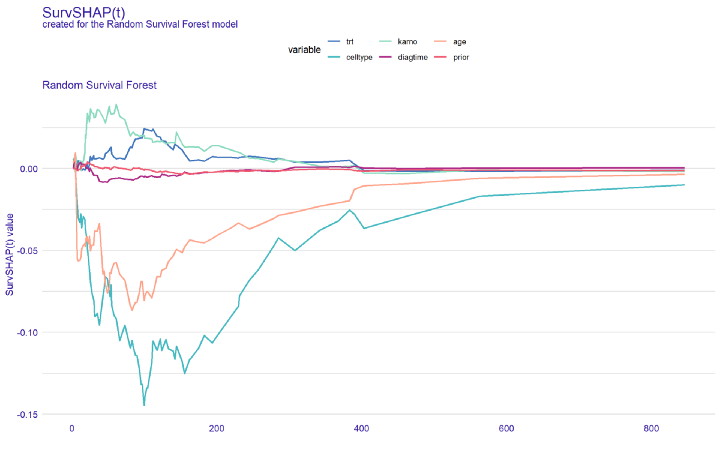

SurvSHAP(t) explanation

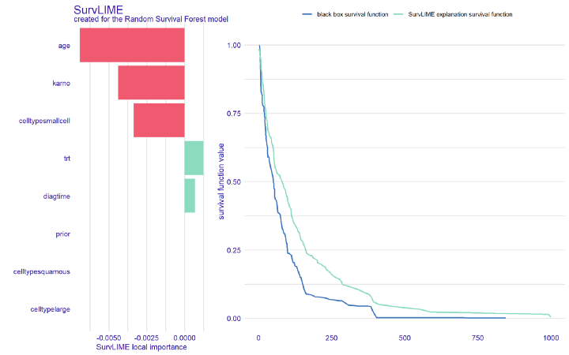

SurvLIME explanation

# How does the prediction change for a selected observation?

The question “what if?” inspires the next kind of explanation. These are *ceteris paribus* profiles and they help us understand what happens to the prediction of a model when we change a variable for a single observation (patient). It can be used to verify the correctness of a model, for example, we can check if the introduction of treatment would, according to the model, increase the chances of a patient’s survival. These explanations are available via the `predict_profile()` function of `survex`.

Below a *ceteris paribus* explanation for the age variable is presented.

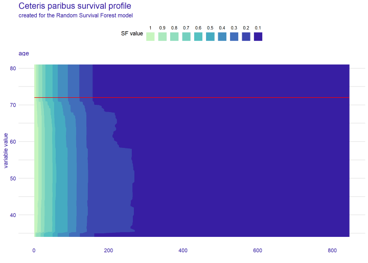

Ceteris paribus profile for the age variable

We see that if the patient was younger, they would have higher chances of survival for this particular observation.

# Measuring performance

The performance of models used for making decisions, especially in crucial fields such as medicine, is critical to the users. `survex` allows for measuring and comparison of models via the `model_performance()` function. The performance of survival models can be measured in different ways — some of the metrics are time-dependent, that is, they assess the performance at specific time points. These include the Brier score (otherwise known as Graf score) and C/D AUC. Others, such as the concordance index and integrated versions of the Brier score and C/D AUC, provide information about the overall performance of the model across the entire time domain.

Brier score is the equivalent of the MSE metric, with minor adjustments allowing to take censored data into account, whereas C/D AUC is the extension of the AUC metric known from classification problems.

Below you can see a comparison of these metrics prepared using `survex` for two models.

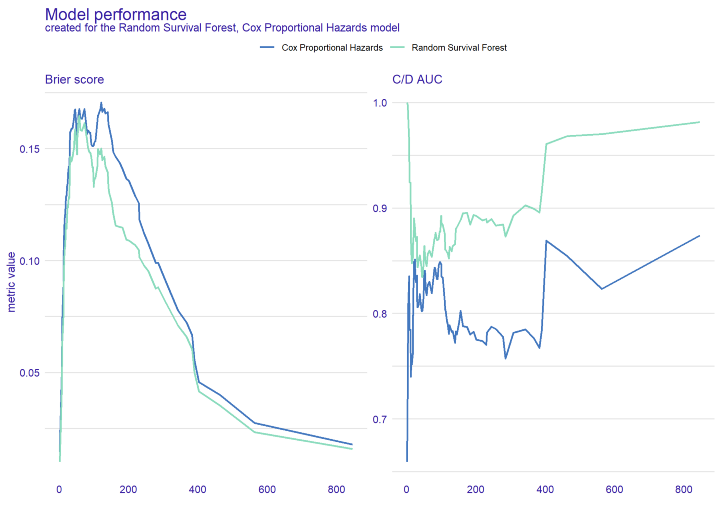

Performance comparison of Cox Proportional Hazards and Random Survival Forest models

# Summary

We hope that the availability of explanation tools for survival models will lead to the adaptation of the explanation aspect in the modeling pipelines for survival analysis.

If this article seems compelling, there’s no better way to find out how this all works than checking on your own. We highly encourage you to try out the explanations provided by survex for yourself. Just type `install.packages("survex")` and start explaining your survival models!

*If you are interested in other posts about explainable, fair, and responsible ML, follow* [*#ResponsibleML*](https://medium.com/responsibleml) *on Medium.*

*In order to see more R related content visit* [*https://www.r-bloggers.com*](https://www.r-bloggers.com/)

Thanks to Mateusz Krzyziński and Anna Kozak

Tools for Explainable, Fair and Responsible ML.

Mateusz Grzyb

·Sep 7

## Large-scale anonymization of medical imaging data in the DICOM format

Xlungs

4 min read

Adam Kozłowski

·Aug 12

## Managing experiment metadata “like a MLOps” — Neptune

Xlungs

5 min read

Adrianna Grudzien

·Jul 21

## LIMEcraft: handcrafted superpixel selection and inspection for Visual eXplanations

Limecraft

4 min read

Anna Kozak

·Jul 7

## How many languages do we need to learn about responsible machine learning? useR! 2022 Conference

R

2 min read

Jakub Wiśniewski

·Jun 14

## RadioTator: A Tailored Tool for Rapid Medical Text Annotation

Radiology

4 min read

Beverly Wang

## Model Explainability: LIME & SHAP

Mathias Grønne

in

Towards Data Science

## Introduction to Embedding, Clustering, and Similarity

Prabowo Yoga Wicaksana

in

MLearning.ai

## Feature Selection Methods

Ansuman Das

## Explainable AI(XAI) Using Shapash Library

Status

Writers

Blog

Careers

Privacy

Terms

About

Knowable